# Setup

**Last updated:** 2017-01-04

**Code version:** a9bcd06b8f2e8f4ce6f91fd823e2e15fe72302ed

```r
library("knitr")
opts_chunk$set(cache = FALSE)
```

I ignore the interaction term for most analyses because it is uninteresting. Evidence below. Mainly, because there are DE genes between resistant and susceptible individuals in the non-infected state but not the infected state, the interaction term is partially redundant with the contrast of susceptibility status in the non-infected state (Pearson's r ~= 0.27 between their p-values).

## Setup

```r
library("limma")
library("plyr")
library("dplyr")
library("tidyr")
library("ggplot2")
library("cowplot")
library("gplots")
```

Load limma results produced by file `../code/main-limma.R`.

```r
v2 <- readRDS("../data/results-limma-voom.rds")
fit2 <- readRDS("../data/results-limma-fit.rds")
results <- readRDS("../data/results-limma-stats.rds")
```

## Overlap of significant genes

```r
ldply(results, function(x) sum(x$qvalue < .1), .id = "test")
```

```
##           test    V1
## 1    status_ni   645
## 2    status_ii     0
## 3 treat_resist 11336
## 4 treat_suscep 11336
## 5     interact     1
```

```r
de_list <- llply(results, function(x) rownames(x)[x$qvalue < .1])
lapply(de_list, length)
```

```
## $status_ni
## [1] 645
##
## $status_ii
## [1] 0
##
## $treat_resist
## [1] 11336
##
## $treat_suscep
## [1] 11336
##
## $interact
## [1] 1
```

```r
(interaction_sub <- subset(results[["interact"]], qvalue < .1))
```

```
##                      logFC  AveExpr         t      P.Value adj.P.Val
## ENSG00000086061 -0.4325527 8.081082 -3.940622 0.0002912036 0.3918652
##                          B      lfsr       lfdr     qvalue    svalue
## ENSG00000086061 0.05162222 0.1106749 0.09934176 0.09934176 0.1106749
```

```r
interaction_gene <- rownames(interaction_sub)
stopifnot(length(interaction_gene) == 1)
(interaction_gene_results <- ldply(results, function(x) x[interaction_gene, ], .id = "test"))
```

```
##           test      logFC  AveExpr         t      P.Value    adj.P.Val
## 1    status_ni  0.2643800 8.081082  2.728405 9.152774e-03 2.754565e-01
## 2    status_ii -0.1681727 8.081082 -1.726909 9.129718e-02 9.006179e-01
## 3 treat_resist  1.2393931 8.081082 24.080565 9.703344e-27 4.073967e-25
## 4 treat_suscep  0.8068404 8.081082  8.302467 1.655933e-10 1.381285e-09
## 5     interact -0.4325527 8.081082 -3.940622 2.912036e-04 3.918652e-01
##             B         lfsr         lfdr       qvalue        svalue
## 1 -2.74220963 7.703933e-02 6.186699e-02 3.822740e-02  4.704350e-02
## 2 -4.25594614 7.860995e-01 7.687762e-01 6.774128e-01  6.875276e-01
## 3 50.78061703 1.735415e-26 1.735415e-26 2.116428e-27 -5.008525e-18
## 4 13.49281404 5.610880e-10 4.177791e-10 4.240435e-11  5.851770e-11
## 5  0.05162222 1.106749e-01 9.934176e-02 9.934176e-02  1.106749e-01
```

```r
interaction_gene_results$test[interaction_gene_results$qvalue < 0.1]
```

```
## [1] status_ni    treat_resist treat_suscep interact
## Levels: status_ni status_ii treat_resist treat_suscep interact
```

[ENSG00000086061 at Ensembl](http://useast.ensembl.org/Homo_sapiens/Gene/Summary?db=core;g=ENSG00000086061;r=9:33025211-33039907;t=ENST00000330899)

## Visualization

Visualizing the one gene that is significantly DE for the interaction term.

```r
plot_gene <- function(v, g) {
  # v - An EList object containing log2 counts per million
  # g - character vector of a single gene
  stopifnot(class(v) == "EList",
            is.character(g), length(g) == 1)
  library("tidyr")
  single_gene <- v$E[g, ]
  single_gene_long <- gather_(as.data.frame(single_gene),
                              gather_cols = colnames(single_gene))
  # For some reason, the argument value_col wouldn't work
  colnames(single_gene_long) <- "log2cpm"
  single_gene_long$sample <- rownames(single_gene_long)
  single_gene_long <- separate_(single_gene_long, col = "sample", sep = "-",
                                into = c("individual", "status", "treatment"))
  single_gene_long$status <- factor(single_gene_long$status, levels = c("resist", "suscep"))
  single_gene_long$treatment <- factor(single_gene_long$treatment, levels = c("noninf", "infect"))
  ggplot(single_gene_long, aes(x = treatment, y = log2cpm, fill = status)) +
    geom_boxplot() +
    labs(title = g, x = "Treatment", y = expression("Expression level (" * log[2] * " cpm)"))
}
```

As expected from the DE results, the difference in the infected state is not very impressive. Likely the interaction term is significant mainly because the direction of the fold difference between susceptible and resistant individuals is in the opposite direction for the non-infected and infected states.

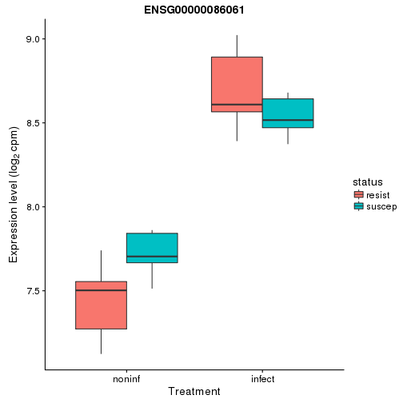

```r
plot_gene(v2, interaction_gene)
```

## Histogram of p-values

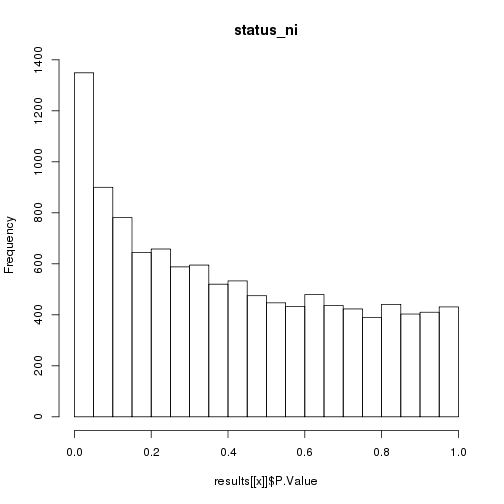

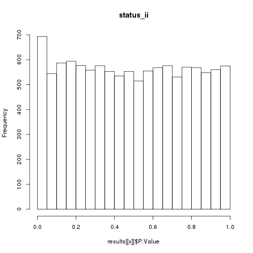

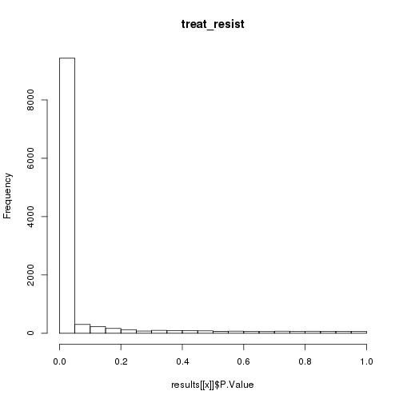

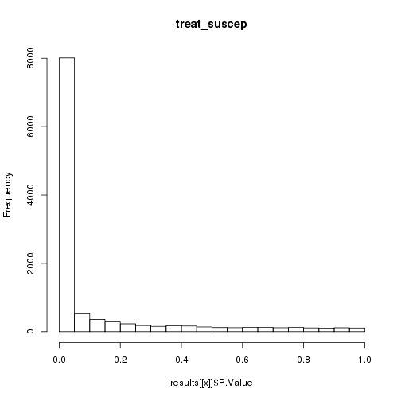

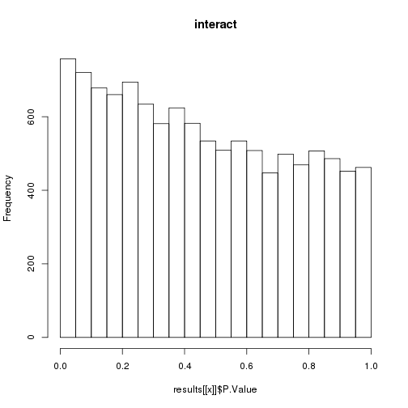

```r
# http://stackoverflow.com/a/3562030/2483477
l_ply(names(results), function(x) hist(results[[x]]$P.Value, main = x))
```

## Pairwise relationship of p-values

```r
pval <- do.call(cbind, lapply(results, function(x) x$P.Value))
(pval_cor <- cor(pval))
```

```
##               status_ni   status_ii treat_resist treat_suscep    interact
## status_ni    1.00000000  0.07018360  0.024906783   0.03388302 0.266942014
## status_ii    0.07018360  1.00000000 -0.013542136  -0.02226471 0.057854553
## treat_resist 0.02490678 -0.01354214  1.000000000   0.43503594 0.003403788
## treat_suscep 0.03388302 -0.02226471  0.435035943   1.00000000 0.032322252
## interact     0.26694201  0.05785455  0.003403788   0.03232225 1.000000000
```

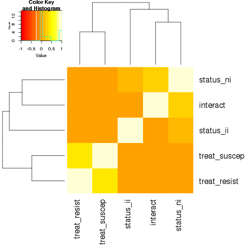

```r
heatmap.2(pval_cor, trace = "none", margins = c(9, 9))
```

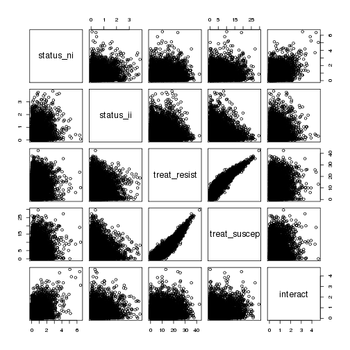

```r
pairs(-log10(pval))
```

## Relationship between logFC of contrasts and significance of interaction term

status_ni

```r
cor(abs(results[["status_ni"]]$logFC), -log10(results[["interact"]]$P.Value))
```

```
## [1] 0.2393309
```

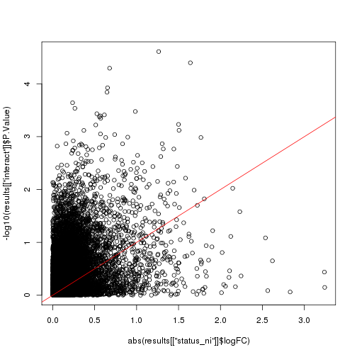

```r
plot(abs(results[["status_ni"]]$logFC), -log10(results[["interact"]]$P.Value))
abline(0, 1, col = "red")
```

status_ii

```r
cor(abs(results[["status_ii"]]$logFC), -log10(results[["interact"]]$P.Value))
```

```
## [1] 0.0314485
```

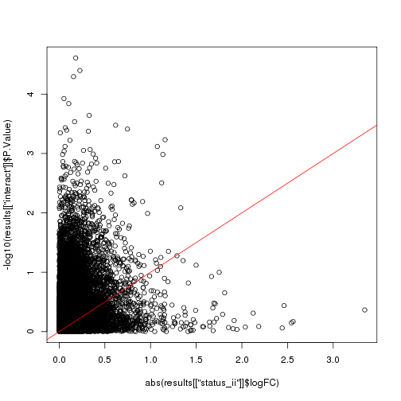

```r
plot(abs(results[["status_ii"]]$logFC), -log10(results[["interact"]]$P.Value))
abline(0, 1, col = "red")
```

treat_resist

```r
cor(abs(results[["treat_resist"]]$logFC), -log10(results[["interact"]]$P.Value))
```

```
## [1] 0.03108656
```

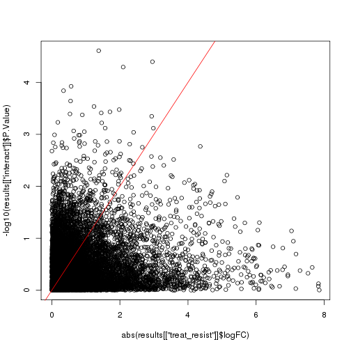

```r
plot(abs(results[["treat_resist"]]$logFC), -log10(results[["interact"]]$P.Value))
abline(0, 1, col = "red")
```

treat_suscep

```r
cor(abs(results[["treat_suscep"]]$logFC), -log10(results[["interact"]]$P.Value))
```

```
## [1] 0.07695691
```

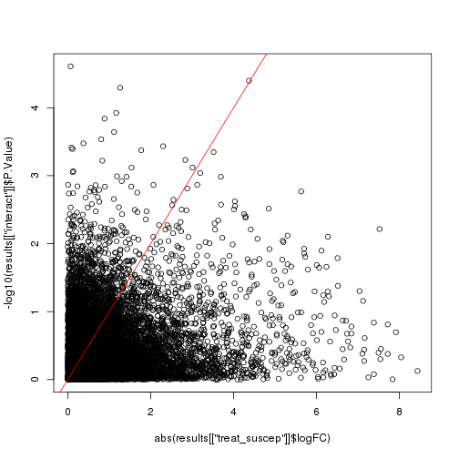

```r
plot(abs(results[["treat_suscep"]]$logFC), -log10(results[["interact"]]$P.Value))
abline(0, 1, col = "red")
```

interact (best-case scenario)

```r
cor(abs(results[["interact"]]$logFC), -log10(results[["interact"]]$P.Value))
```

```
## [1] 0.6817094
```

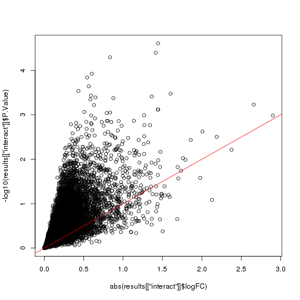

```r
plot(abs(results[["interact"]]$logFC), -log10(results[["interact"]]$P.Value))
abline(0, 1, col = "red")
```